# assignment_10B

## Approach

### Brainstorm

```r
library(tidyverse)
library(jsonlite)
df <- fromJSON("https://api.nobelprize.org/2.1/nobelPrizes")
glimpse(df)
```

[output not shown]

[output cut: 23 more lines]

```
  .. ..$ :'data.frame': 1 obs. of  7 variables:
  .. ..$ :'data.frame': 1 obs. of  7 variables:
  .. ..$ :'data.frame': 1 obs. of  7 variables:
 $ meta       :List of 6
  ..$ offset    : int 0
  ..$ limit     : int 25
  ..$ count     : int 682
  ..$ terms     : chr "https://www.nobelprize.org/about/terms-of-use-for-api-nobelprize-org-and-data-nobelprize-org/"
  ..$ license   : chr "https://www.nobelprize.org/about/terms-of-use-for-api-nobelprize-org-and-data-nobelprize-org/#licence"
  ..$ disclaimer: chr "https://www.nobelprize.org/about/terms-of-use-for-api-nobelprize-org-and-data-nobelprize-org/#disclaimer"
 $ links      :List of 4
  ..$ first: chr "http://nobel-external-api-app.azurewebsites.net/2.1/nobelPrizes?offset=0&limit=25"
  ..$ self : chr "http://nobel-external-api-app.azurewebsites.net/2.1/nobelPrizes?offset=0&limit=25"
  ..$ next : chr "http://nobel-external-api-app.azurewebsites.net/2.1/nobelPrizes?offset=25&limit=25"
  ..$ last : chr "http://nobel-external-api-app.azurewebsites.net/2.1/nobelPrizes?offset=675&limit=25"
```

Lot of nested dataframes and lists. Seems better to read the [documentation](https://app.swaggerhub.com/apis/NobelMedia/NobelMasterData/2.0) where it’s better to create an https request. Unless the request is to use `https://api.nobelprize.org/2.1/nobelPrizes`?

### Questions

After understanding the data, I can come up with the following questions:

- Did Friedrich Nietzsche ever win a Nobel Prize?
- What was Betrand Russell’s motivation for winning a prize?
- Who won the Nobel Prize in Literature in 2010-2020?
- What is the overall ratio of male to female Nobel Prize laureates? Among the five countries with the most birthed laureates, what is the male-to-female ratio in each country?

#### Nietzsche

Bool response for the query: `http://api.nobelprize.org/2.0/laureates?name=Friedrich%20Nietzsche`

#### Betrand Russell

Return motivation columns from the query: `http://api.nobelprize.org/2.0/laureates?name=Betrand%20Russell`

#### Nobel Prize Literature 2010-2020

`http://api.nobelprize.org/2.0/laureates?nobelPrizeYear=2010&yearTo=2020&nobelPrizeCategory=lit`

#### Ratio of male to Female Nobel Prize laureates and country outliers.

`http://api.nobelprize.org/2.0/laureates`

## Codeurl

### packages

```r
library(tidyverse)
library(jsonlite)
library(tidyr)
library(stringr)
```

### set up

```r
url <- "https://api.nobelprize.org/2.1"

# calling function makes it easier to answer the different questions
get_api <- function(path) {
  fromJSON(path, flatten = TRUE)
}
```

### Q1: Did Friedrich Nietzsche ever win a Nobel Prize?

```r
nietzsche <- get_api(
  paste0(url, "/laureates?name=Friedrich%20Nietzsche")
)

if (length(nietzsche$laureates) > 0) "Yes" else "No"
```

```
[1] "No"
```

### Q2: What was he motivation for Bertrand Russell’s Nobel Prize?

```r
russell <- get_api(
  paste0(url, "/laureates?name=Bertrand%20Russell")
)

russell$laureates|>
  select(fullName.en, nobelPrizes) |>
  unnest(cols = nobelPrizes) |>
  select(fullName.en, awardYear, category.en, motivation.en) |>
  pull(motivation.en)
```

```
[1] "in recognition of his varied and significant writings in which he champions humanitarian ideals and freedom of thought"
```

```r
lit <- get_api(
  paste0(url, "/nobelPrizes?nobelPrizeCategory=literature&awardYear=2010&yearTo=2020")
)

lit_winners <- lit$nobelPrizes|>
  select(awardYear, laureates)|>
  unnest(cols = laureates) |>
  transmute(
    year = awardYear,
    winner = coalesce(knownName.en, fullName.en)
  )

lit_winners
```

```
# A tibble: 31 × 2
   year  winner
   <chr> <chr>
 1 1901  Jacobus H. van 't Hoff
 2 1901  Sully Prudhomme
 3 1901  Henry Dunant
 4 1901  Frédéric Passy
 5 1901  Wilhelm Conrad Röntgen
 6 1901  Emil von Behring
 7 1902  Emil Fischer
 8 1902  Theodor Mommsen
 9 1902  Élie Ducommun
10 1902  Albert Gobat
# ℹ 21 more rows
```

### Q4: Overall male-to-female ratio, and the ratio in the 5 birth countries with the most laureates

```r
all_laureates <- get_api(
  paste0(url, "/laureates?limit=2000")
)

laureates_df <- all_laureates$laureates|>
  transmute(
    name = coalesce(knownName.en, fullName.en),
    gender,
    birth_country = birth.place.country.en
  )

overall_ratio <- laureates_df |>
  filter(gender %in% c("male", "female")) |>
  count(gender) |>
  pivot_wider(names_from = gender, values_from = n) |>
  mutate(male_to_female_ratio = male / female)

overall_ratio
```

```
# A tibble: 1 × 3
  female  male male_to_female_ratio
   <int> <int>                <dbl>
1     67   923                 13.8
```

```r
top5_countries <- laureates_df |>
  filter(!is.na(birth_country)) |>
  count(birth_country, sort = TRUE) |>
  slice_head(n = 5)

top5_countries
```

```
   birth_country   n
1            USA 296
2 United Kingdom  94
3        Germany  80
4         France  60
5          Japan  30
```

```r
country_ratios <- laureates_df |>
  filter(birth_country %in% top5_countries$birth_country,
         gender %in% c("male", "female")) |>
  count(birth_country, gender) |>
  pivot_wider(
    names_from = gender,
    values_from = n,
    values_fill = 0
  )

if (!"male" %in% names(country_ratios)) {
  country_ratios$male <- 0L
}

if (!"female" %in% names(country_ratios)) {
  country_ratios$female <- 0L
}

country_ratios <- country_ratios |>
  mutate(
    total = male + female,
    male_to_female_ratio = if_else(female == 0, NA_real_, male / female),
    ratio_text = if_else(
      female == 0,
      "No women; 100% male",
      paste0(round(male / female, 2), ":1")
    )
  ) |>
  arrange(desc(total))

country_ratios |>
  arrange(male_to_female_ratio)
```

```
# A tibble: 5 × 6
  birth_country  female  male total male_to_female_ratio ratio_text
  <chr>           <int> <int> <int>                <dbl> <chr>
1 France              6    54    60                  9   9:1
2 USA                18   278   296                 15.4 15.44:1
3 Germany             3    77    80                 25.7 25.67:1
4 United Kingdom      0    94    94                 NA   No women; 100% male
5 Japan               0    30    30                 NA   No women; 100% male
```

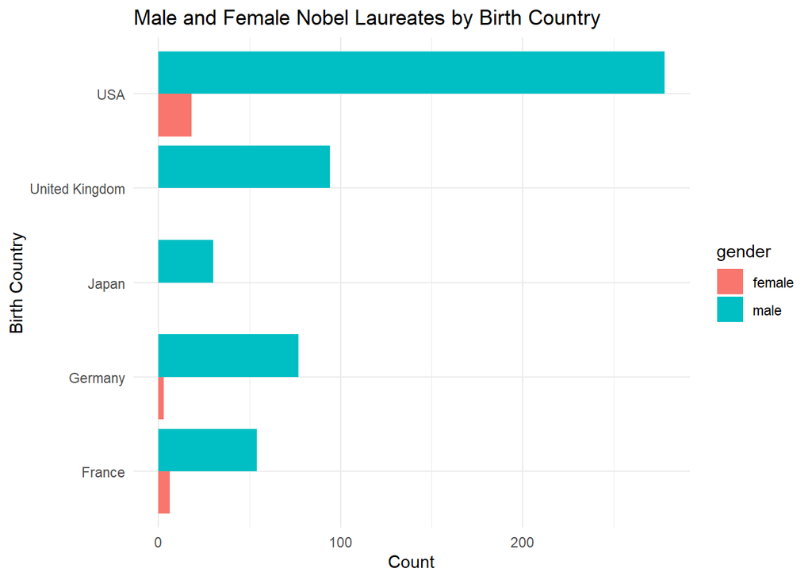

```r
country_ratios |>
  select(birth_country, male, female) |>
  pivot_longer(cols = c(male, female),
               names_to = "gender",
               values_to = "count") |>
  ggplot(aes(x = birth_country, y = count, fill = gender)) +
  geom_col(position = "dodge") +
  coord_flip() +
  labs(
    title = "Male and Female Nobel Laureates by Birth Country",
    x = "Birth Country",
    y = "Count"
  ) +
  theme_minimal()
```

France has the strongest female representation relative to men, while the United States has the highest raw counts of both female and male laureates. In our sample, countries such as Japan and the U.K. had no female laureates. These results are based on birth_country, not the country where a laureate later lived or grew up.